# Discussion 10 - Demo

Cameron Jones

Week of November 13

# Concept Review

##### Data: Plant Growth

We’re looking at the weights of ten plants which have all been given the same growth treatment. We consider this set of 10 to be a sample from a hypothetical set of giving all possible plants this treatment.

We are interested in the mean of that population.

```r
PlantGrowth %>% filter(group == "ctrl")
```

```
##    weight group
## 1    4.17  ctrl
## 2    5.58  ctrl
## 3    5.18  ctrl
## 4    6.11  ctrl
## 5    4.50  ctrl
## 6    4.61  ctrl
## 7    5.17  ctrl
## 8    4.53  ctrl
## 9    5.33  ctrl
## 10   5.14  ctrl
```

### Homework-Level Single Mean Inference

Is there evidence the true mean weight of the control plants is something different than 5?

**Model**

$$Y_i \sim D(\mu, \sigma)$$

We assert that each control plant’s weight, $Y_i$, comes from some unimportant distribution $D$ (doesn’t have to be normal, by the Central Limit Theorem) which has mean $\mu$ and standard deviation $\sigma$. Again, we are interested in $\mu$.

**Hypotheses**

$$H_0: \mu = 5$$

$$H_A: \mu \neq 5$$

**Test Statistic**

As we said above, the individual $Y_i$ plant weights follow some unknown and irrelevant distribution $D(\mu, \sigma)$. However, usefully, we know by the central limit theorem that the sample mean $\bar{Y}$ has the distribution:

$$\bar{Y} \sim Normal(\mu, \frac{\sigma}{\sqrt{n}})$$

This can be rewritten as:

$$\frac{\bar{Y}-\mu}{\sigma/\sqrt{n}} \sim Normal(0, 1)$$

Where n is the size of our sample (10 here).

This would be really nice… if we knew $\sigma$. We don’t know the true $\sigma$. We can estimate $\sigma$ with $\hat{\sigma}$, the sample standard deviation. If we replace $\sigma$ with $\hat{\sigma}$ in the formula, the distribution is no longer normal, but something slightly more random called a t distribution.

$$\frac{\bar{Y}-\mu}{\hat{\sigma}/\sqrt{n}} \sim t(n-1)$$

A couple notes on the t distribution:

- Unlike Binomial and Normal which have two, the t distribution has just one parameter: the “degrees of freedom”, n-1 here
- It is very similar to the standard normal distribution, especially for large n; see lecture example

**Sampling Distribution**

Under the null hypothesis which states that $\mu = 5$,

$$\frac{\bar{Y}-5}{\hat{\sigma}/\sqrt{n}} \sim t(n-1)$$

**Outcomes**

We observe the sample mean and standard deviation:

```r
PlantGrowth %>% filter(group == "ctrl") %>% summarize(sampleMean = mean(weight), sampleSD = sd(weight))
```

```
##   sampleMean  sampleSD
## 1      5.032 0.5830914
```

Our alternative hypothesis is two-sided, so anything as far or further from the null value of 5 constitutes evidence against the null. Therefore, any value of the sample mean outside the range [4.968, 5.032] is evidence.

From the sampling distribution, which is $t(n-1) = t(10-1) = t(9)$, this is any value outside the range [$\frac{4.968-5}{0.58/\sqrt{10}}, \frac{5.032-5}{0.58/\sqrt{10}}$].

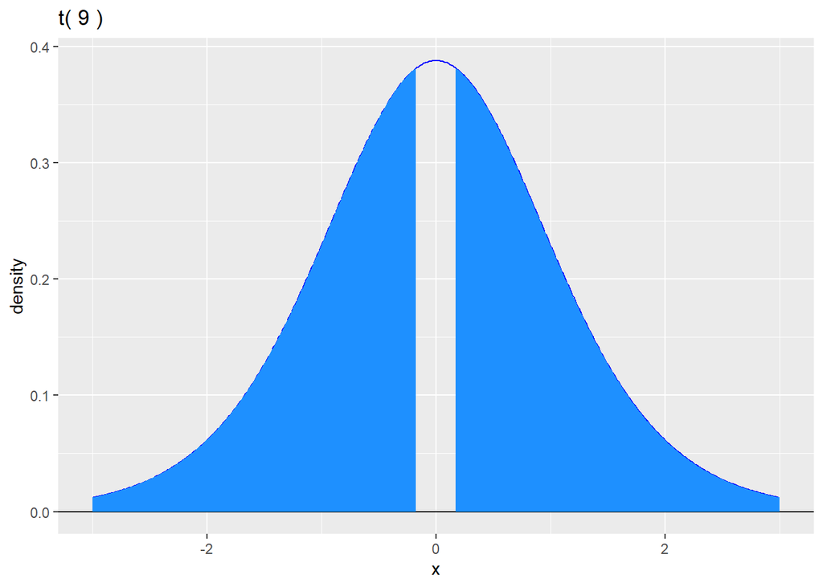

```r
# Note that we are plotting the transformed t-scores; the points are not the raw data of 4.968 and 5.032.

gt(df = 9) +
  geom_t_fill(df = 9, b = (4.968-5)/(0.58/sqrt(10)), fill = "dodgerblue") +
  geom_t_fill(df = 9, a = (5.032-5)/(0.58/sqrt(10)), fill = "dodgerblue") +
  xlim(-3, 3)
```

**p-value**

Just like pnorm and pbinom, pt returns $P(X \leq q)$, where $X \sim t(df)$, and you only have to specify q and df.

```r
sampleMean = 5.032
sampleSD = 0.5830914
n = 10

StdError = sampleSD/sqrt(n)

# That complicated formula for leftPoint is just getting the equidistant point, 4.968, then subtracting that from 5. You can hard code it if you want.

# If you are adapting this code to another problem; make sure you know whether your observed sample mean is right or left of the null value!

leftPoint = (5-(sampleMean-5)-5)/StdError
rightPoint = (sampleMean - 5)/StdError

# area left of range + area right of range
pt(leftPoint, df = n-1) + (1 - pt(rightPoint, df = n-1))
```

```
## [1] 0.8660633
```

**Interpret p-value in context**

We do NOT have strong evidence to say the true average weight differs from 5.

**Confidence Interval**

Recall our formula for a confidence interval is:

$$(\text{Point Estimate of } \mu) \pm (\text{Quantile Score})(\text{Std.
Error})$$

Our point estimate of $\mu$ is $\bar{Y} = 5.032$.

Before, our quantile scores were coming from the standard normal distribution; now they are coming from the t(n-1) distribution.

We calculate the standard error above; $SE(\bar{Y}) = \hat{\sigma}/\sqrt{n}$.

```r
q_score = qt(0.975, df = 9) # This is 2.26; not 1.96!

sampleMean - q_score * StdError
```

```
## [1] 4.614882
```

```r
sampleMean + q_score * StdError
```

```
## [1] 5.449118
```

We can verify our p-value and confidence interval with the t.test function.

```r
data = PlantGrowth %>% filter(group == "ctrl") %>% pull(weight)
t.test(data, mu = 5)
```

```
##
##  One Sample t-test
##
## data:  data
## t = 0.17355, df = 9, p-value = 0.8661
## alternative hypothesis: true mean is not equal to 5
## 95 percent confidence interval:
##  4.614882 5.449118
## sample estimates:
## mean of x
##     5.032
```